# Assignment 1

8. Plot three network graphs (with legend) setting a different the vertex colour for each level of the nodal attributes using the “kamadakawai” layout. [**10 marks**]

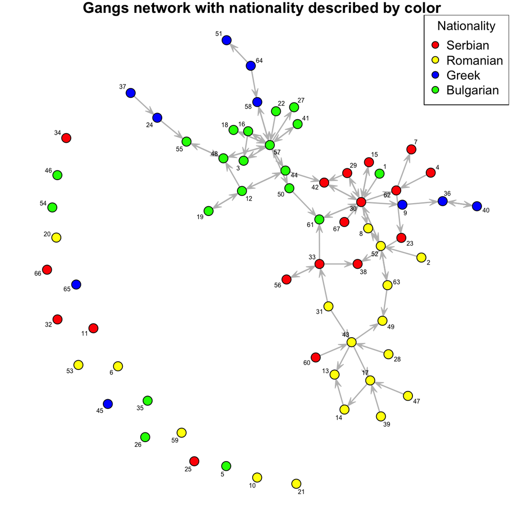

```r
set.seed(5)
par(mar = rep(1, 4))
plot(y,
     label = 1:numVertex,
     label.cex = 0.5,
     vertex.cex = 1,
     edge.col = "grey",
     vertex.col = nationalityColList[y %v% "nationality"],
     main = "Gangs network with nationality described by color",
     mode = "kamadakawai")

legend("topright",
       pt.bg  = nationalityColList[sort(unique(y %v% "nationality"))],
       pt.cex = 1.2,
       pch    = 21,
       legend = nationalityList[sort(unique(y %v% "nationality"))],
       title  = 'Nationality')
```

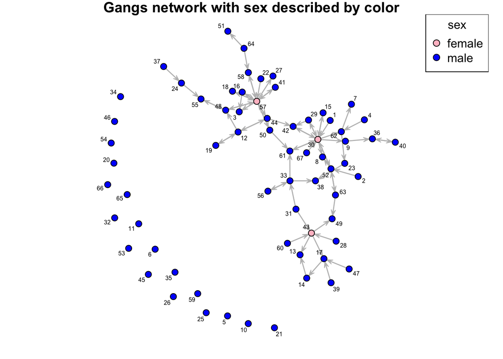

```r
set.seed(5)
par(mar = rep(1, 4))
plot(y,
     label = 1:numVertex,
     label.cex = 0.5,
     vertex.cex = 1,
     edge.col = "grey",
     vertex.col = sexColList[y %v% "sex"],
     main = "Gangs network with sex described by color",
     mode = "kamadakawai")

legend("topright",
       pt.bg  = sexColList[sort(unique(y %v% "sex"))],
       pt.cex = 1.2,
       pch    = 21,
       legend = sexList[sort(unique(y %v% "sex"))],
       title  = 'sex')
```

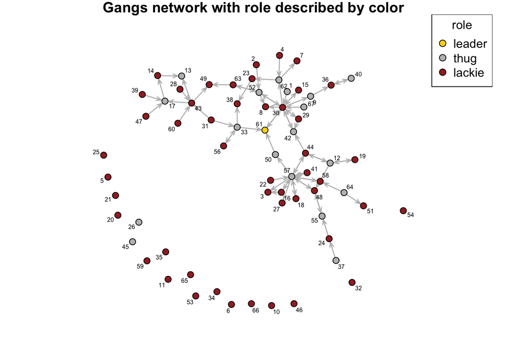

```r
set.seed(4)
par(mar = rep(1, 4))
plot(y,
     label = 1:numVertex,
     label.cex = 0.5,
     vertex.cex = 1,
     edge.col = "grey",
     vertex.col = roleColList[y %v% "role"],
     main = "Gangs network with role described by color",
     mode = "kamadakawai")

legend("topright",
       pt.bg  = roleColList[sort(unique(y %v% "role"))],
       pt.cex = 1.2,
       pch    = 21,
       legend = roleList[sort(unique(y %v% "role"))],
       title  = 'role')
```

*Comment*  
On nationality plot, apart from some isolated individuals, we can see how members of a same nationality are clustered together, with the exception of the greeks, who seem to have 3 separate small groups. Also Romanians only seem to have direct links with Serbians.

On the sex plot, we actually don’t see clustering by sex as the few females in the plot do not have direct links between each other.

On the role plot might suggest a hyerarchy of some sorts, we see that lakies are the majority. Thugs are usually surrounded by lackies, and there is only one leader that has two in edges from thugs but, for some reason, has also a bidiretional edge with a lackie.

### Statistical modelling [**20 marks**]

Estimate, interpret and assess the exponential-family random graph model specified by the following network effects:

- density;
- reciprocity;
- reciprocity between actors with the same role;
- homophily between actors with the same nationality.

```r
#ergmodel_1 <- y ~
#  edges + # density
#  mutual + # reciprocity
#  mutual(same = "role") + # reciprocity between actors with the same role
#  nodematch('nationality') # homophily between actors with the same nationality


ergmodel_1 <- y ~ edges + mutual + mutual(same = "role") + nodematch('nationality')
#TODO: this is failing intermettently, find a solution to fix it.
mle.ergmodel_1 <- ergm(ergmodel_1)
```

[output not shown]

[output not shown]

[output not shown]

[output not shown]

[output not shown]

[output not shown]

[output not shown]

[output not shown]

[output not shown]

[output not shown]

[output not shown]

[output not shown]

[output not shown]

[output not shown]

[output not shown]

[output not shown]

[output not shown]

[output not shown]

[output not shown]

[output not shown]

[output not shown]

[output not shown]

[output not shown]

[output not shown]

[output not shown]

[output not shown]

[output not shown]

[output not shown]

[output not shown]

[output not shown]

[output not shown]

[output not shown]

[output not shown]

[output not shown]

[output not shown]

[output not shown]

[output not shown]

[output not shown]

[output not shown]

[output not shown]

[output not shown]

[output not shown]

[output not shown]

[output not shown]

[output not shown]

[output not shown]

[output not shown]

[output not shown]

[output not shown]

[output not shown]

[output not shown]

[output not shown]

[output not shown]

[output not shown]

[output not shown]

[output not shown]

[output not shown]

[output not shown]

[output not shown]

[output not shown]

[output not shown]

[output not shown]

[output not shown]

[output not shown]

[output not shown]

[output not shown]

[output not shown]

[output not shown]

[output not shown]

[output not shown]

[output not shown]

[output not shown]

[output not shown]

[output not shown]

[output not shown]

[output not shown]

[output not shown]

[output not shown]

[output not shown]

[output not shown]

[output not shown]

[output not shown]

[output not shown]

[output not shown]

[output not shown]

[output not shown]

[output not shown]

[output not shown]

[output not shown]

[output not shown]

[output not shown]

[output not shown]

[output not shown]

[output not shown]

[output not shown]

[output not shown]

[output not shown]

[output not shown]

[output not shown]

[output not shown]

[output not shown]

[output not shown]

[output not shown]

[output not shown]

[output not shown]

[output not shown]

[output not shown]

[output not shown]

[output not shown]

[output not shown]

[output not shown]

[output not shown]

[output not shown]

[output not shown]

[output not shown]

[output not shown]

[output not shown]

[output not shown]

[output not shown]

[output not shown]

```r
summary(mle.ergmodel_1)
```

```
## Call:
## ergm(formula = ergmodel_1)
##
## Monte Carlo Maximum Likelihood Results:
##
##                         Estimate Std. Error MCMC % z value Pr(>|z|)
## edges                   -22.9041 26754.9600    100  -0.001    0.999
## mutual                    4.4743     0.4341      0  10.306   <1e-04 ***
## mutual.role             -55.1657         NA     NA      NA       NA
## nodematch.nationality    19.4414 26754.9600    100   0.001    0.999
## ---
## Signif. codes:  0 '***' 0.001 '**' 0.01 '*' 0.05 '.' 0.1 ' ' 1
##
##      Null Deviance: 6130  on 4422  degrees of freedom
##  Residual Deviance: 1224  on 4418  degrees of freedom
##
## AIC: 1232  BIC: 1257  (Smaller is better. MC Std. Err. = 0.1881)
```

*Comment*

```r
#ATTENTION! the model above is failing intermittently
#and not working at all when using knit
#this is the actual model summary when it works:
Call:
ergm(formula = ergmodel_1)

Monte Carlo Maximum Likelihood Results:

                      Estimate Std. Error MCMC % z value Pr(>|z|)
edges                  -5.6006     0.2585      0 -21.666  < 1e-04 ***
mutual                  4.6172     0.4440      0  10.399  < 1e-04 ***
mutual.role            -2.4866     0.7612      0  -3.266  0.00109 **
nodematch.nationality   1.9692     0.2931      0   6.718  < 1e-04 ***
---
Signif. codes:  0 ‘***’ 0.001 ‘**’ 0.01 ‘*’ 0.05 ‘.’ 0.1 ‘ ’ 1

     Null Deviance: 6130.2  on 4422  degrees of freedom
 Residual Deviance:  556.2  on 4418  degrees of freedom

AIC: 564.2  BIC: 589.8  (Smaller is better. MC Std. Err. = 0.6127)
```

Goodness of fit:

```r
gof(mle.ergmodel_1)
```

```
##
## Goodness-of-fit for in-degree
##
##          obs min  mean max MC p-value
## idegree0  30  18 26.47  40       0.42
## idegree1  17  12 23.48  37       0.16
## idegree2  12   3 11.77  24       1.00
## idegree3   6   0  3.95  10       0.42
## idegree4   0   0  1.11   3       0.62
## idegree5   0   0  0.16   2       1.00
## idegree6   0   0  0.05   1       1.00
## idegree7   2   0  0.01   1       0.00
##
## Goodness-of-fit for out-degree
##
##          obs min  mean max MC p-value
## odegree0  26  15 26.11  38       1.00
## odegree1  27  15 23.81  34       0.48
## odegree2   7   4 11.92  21       0.24
## odegree3   5   0  4.03  10       0.80
## odegree4   0   0  0.94   4       0.74
## odegree5   0   0  0.16   1       1.00
## odegree6   0   0  0.03   1       1.00
## odegree8   1   0  0.00   0       0.00
## odegree9   1   0  0.00   0       0.00
##
## Goodness-of-fit for edgewise shared partner
##
##      obs min  mean max MC p-value
## esp0  66  40 61.15  80       0.64
## esp1   7   0  3.31  14       0.26
## esp2   0   0  0.02   1       1.00
##
## Goodness-of-fit for minimum geodesic distance
##
##      obs  min    mean  max MC p-value
## 1     73   40   64.48   87       0.44
## 2    154   25   59.36   94       0.00
## 3    127   15   44.44   90       0.00
## 4    101    6   28.60   68       0.00
## 5     86    0   15.68   49       0.00
## 6     54    0    7.09   33       0.00
## 7     37    0    2.81   17       0.00
## 8     16    0    1.11   10       0.00
## 9      7    0    0.34    9       0.04
## 10     3    0    0.10    3       0.06
## 11     0    0    0.06    2       1.00
## 12     0    0    0.01    1       1.00
## Inf 3764 3997 4197.92 4316       0.00
##
## Goodness-of-fit for model statistics
##
##                       obs min  mean max MC p-value
## edges                  73  40 64.48  87       0.44
## mutual                 17   9 16.38  25       1.00
## mutual.role             2   0  0.00   0       0.00
## nodematch.nationality  59  40 64.48  87       0.56
```

```r
#ATTENTION! as the model above is failing on knit, this is the actual
#goodness of fit fot he model when it works
#(notice that here mutual role actually has a p-value of 1 instead of 0)
Goodness-of-fit for in-degree

         obs min  mean max MC p-value
idegree0  30  14 21.94  36       0.14
idegree1  17  14 24.88  35       0.06
idegree2  12   6 13.02  22       0.96
idegree3   6   0  5.15  11       0.82
idegree4   0   0  1.62   6       0.38
idegree5   0   0  0.32   2       1.00
idegree6   0   0  0.07   1       1.00
idegree7   2   0  0.00   0       0.00

Goodness-of-fit for out-degree

         obs min  mean max MC p-value
odegree0  26  12 22.77  39       0.52
odegree1  27  14 23.39  34       0.42
odegree2   7   6 13.59  21       0.08
odegree3   5   0  5.22  12       1.00
odegree4   0   0  1.60   5       0.50
odegree5   0   0  0.35   3       1.00
odegree6   0   0  0.07   2       1.00
odegree7   0   0  0.01   1       1.00
odegree8   1   0  0.00   0       0.00
odegree9   1   0  0.00   0       0.00

Goodness-of-fit for edgewise shared partner

     obs min  mean max MC p-value
esp0  66  38 71.41  90       0.52
esp1   7   0  3.35  13       0.38
esp2   0   0  0.11   2       1.00

Goodness-of-fit for minimum geodesic distance

     obs  min    mean  max MC p-value
1     73   38   74.87   98       0.82
2    154   17   80.33  143       0.00
3    127    5   76.38  164       0.18
4    101    2   65.96  180       0.42
5     86    0   53.54  194       0.44
6     54    0   41.05  203       0.58
7     37    0   29.17  197       0.62
8     16    0   20.09  163       0.80
9      7    0   13.31  130       0.92
10     3    0    9.00  105       0.88
11     0    0    5.36   67       1.00
12     0    0    2.83   41       1.00
13     0    0    1.56   33       1.00
14     0    0    0.66   25       1.00
15     0    0    0.29   18       1.00
16     0    0    0.13   12       1.00
17     0    0    0.08    8       1.00
18     0    0    0.05    5       1.00
19     0    0    0.02    2       1.00
20     0    0    0.01    1       1.00
Inf 3764 2783 3947.31 4360       0.48

Goodness-of-fit for model statistics

                      obs min  mean max MC p-value
edges                  73  38 74.87  98       0.82
mutual                 17   8 17.64  27       0.92
mutual.role             2   0  1.94   6       1.00
nodematch.nationality  59  31 60.40  78       0.92
```